```python
import numpy as np
import matplotlib.pyplot as plt
import scipy.stats as sts
import pandas as pd
import seaborn
import math
%matplotlib inline
```

# Гречишкин Денис ПМ-31

# Лабораторная работа №10

## Задание 1: Сгенерируйте выборку объема n двумерного нормального распределения с параметрами $m_X$, $m_Y$, $\sigma_X$, $\sigma_Y$, и выполните следующие действия:

1) постройте диаграмму рассеяния; 2) постройте гистограммы компонент; 3) найдите выборочные характеристики компонент; 4) найдите выборочное значение коэффициента корреляции Пирсона; 5) постройте доверительный интервал для коэффициента корреляции; 6) проверьте гипотезу о значимости коэффициента корреляции Пирсона. $\newline$ Сопоставьте полученные результаты с известными свойствами двумерного нормального распределения.

## Решение:

## Пункт 1:

```
(-16.151577017792302,
 22.189845601543603,
 -25.264135944238397,
 34.76883270487758)
```

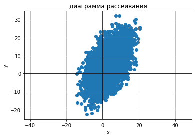

```python
m = [3, 5]
n = 10000
sigmaX = 5
sigmaY = 7
DX = sigmaX**2
DY = sigmaY**2
ro = 0.5
KXY = ro * sigmaX * sigmaY
cov = [[DX, KXY], [KXY, DY]]
Z = np.random.multivariate_normal(m, cov, n)
plt.scatter(Z[:,0], Z[:,1])
plt.grid(True)
plt.title("диаграмма рассеивания")
plt.xlabel('x')
plt.ylabel('y')
plt.axhline(y = 0, color = 'k')
plt.axvline(x = 0, color = 'k')
plt.axis("equal")
```

## Пункт 2: построим гистограммы с помощью функции plt.hist()

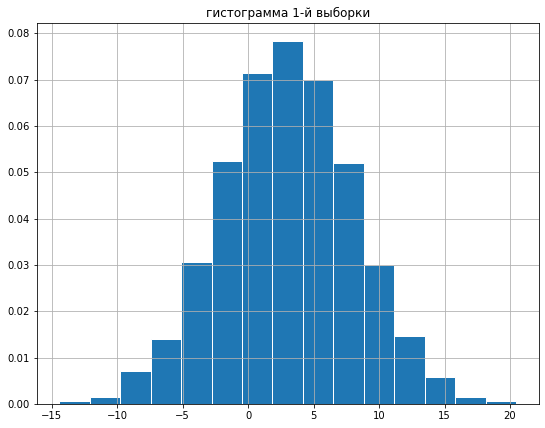

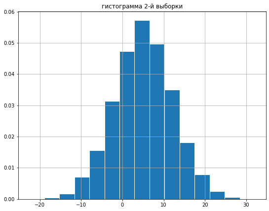

```python
plt.figure(figsize = (9, 7))
plt.hist(Z[:,0], bins = 'sturges', edgecolor = 'white', density = True)
plt.grid(True)
plt.title("гистограмма 1-й выборки")

plt.figure(figsize = (9, 7))
plt.hist(Z[:,1],  bins = 'sturges', edgecolor = 'white', density = True)
plt.grid(True)
plt.title("гистограмма 2-й выборки")
```

## Пункт 3:

```python
Z_01 = Z[:,0]
Z_02 = Z[:,1]

print("ЧИСЛОВЫЕ ХАРАКТЕРИСТИКИ 1-Й ВЫБОРКИ\n")
m_at1 = np.mean(Z_01)
d_at1 = np.var(Z_01, ddof = 1)
mediana_at1 = np.median(Z_01)
print("Выборочное мат ожидание:", m_at1)
print("Исправленная выборочная дисперсия:", d_at1)
print("СКО:", np.sqrt(d_at1))
print("Медиана:", mediana_at1, "\n")
print("ЧИСЛОВЫЕ ХАРАКТЕРИСТИКИ 2-Й ВЫБОРКИ\n")
m_at2 = np.mean(Z_02)
d_at2 = np.var(Z_02, ddof = 1)
mediana_at2 = np.median(Z_02)
print("Выборочное мат ожидание:", m_at2)
print("Исправленная выборочная дисперсия:", d_at2)
print("СКО:", np.sqrt(d_at2))
print("Медиана:", mediana_at2, "\n")
```

```
ЧИСЛОВЫЕ ХАРАКТЕРИСТИКИ 1-Й ВЫБОРКИ

Выборочное мат ожидание: 2.983576775450583
Исправленная выборочная дисперсия: 25.163591126885237
СКО: 5.016332437835957
Медиана: 3.012153690494358

ЧИСЛОВЫЕ ХАРАКТЕРИСТИКИ 2-Й ВЫБОРКИ

Выборочное мат ожидание: 5.068677994668382
Исправленная выборочная дисперсия: 50.243437224627684
СКО: 7.088260521780198
Медиана: 5.024971049552913
```

## Пункт 4: выборочный коэффициент корреляции Пирсона найдем по формуле:

$$\rho_{XY} = \frac{\sum_{i = 1}^n (X[i] - \overline{X})\cdot(Y[i] - \overline{Y})}{(n-1)\cdot\sigma_X\sigma_Y}$$

```python
chislitel = 0
for i in range(len(Z_01)):
    chislitel += (Z_01[i] - m_at1)*(Z_02[i] - m_at2)
rz = chislitel/((n-1)*sigmaX*sigmaY)
print("коэффициент корреляции пирсона ro", rz)
```

```
коэффициент корреляции пирсона ro 0.5140614065022932
```

## Пункт 5:

```python
alpha = 0.1
lev_granitsa = math.tanh(math.atanh(rz) - ((sts.norm(0, 1)).ppf(1-alpha/2))/(np.sqrt(n-3)))
prav_granitsa = math.tanh(math.atanh(rz) + ((sts.norm(0, 1)).ppf(1-alpha/2))/(np.sqrt(n-3)))
print("при уровне значимости alpha =", alpha, "доверительный интервал для коэффициента корреляции Пирсона:\n")
print(lev_granitsa, "< ro <", prav_granitsa)
```

```
при уровне значимости alpha = 0.1 доверительный интервал для коэффициента корреляции Пирсона:

0.5018556092037819 < ro < 0.5260625087216966
```

## Пункт 6: $\newline$

Основная гипотеза: $$H_0: \rho = 0$$ Альтернативная гипотеза: $$H_1: \rho \ne 0$$ Возьмем уровень значимости $\alpha = 0.1$ Будем пользоваться критерием, критическая область которого, учитывая введенную альтернативную гипотезу, определяется неравенством: $$|r| \gt \frac{t_{1-\alpha/2}(n - 2)}{\sqrt{n-2+t_{1-\alpha/2}^2(n - 2)}}$$ Далее, см. комментарии в коде

```python
print("коэффициент корреляции Пирсона ro", rz)
prav_chasch_ner_va = ((sts.t(n-2)).ppf(1-alpha/2))/(np.sqrt(n-2+((sts.t(n-2)).ppf(1-alpha/2))**2))
if(np.abs(rz) > prav_chasch_ner_va):
    print("Основная гипотеза отклоняется: выборочный к-т корреляции Пирсона статистически значим\n")
    print(np.abs(rz), ">", prav_chasch_ner_va, "\n")
else:
    print("Основная гипотеза принимается: выборочный к-т корреляции Пирсона статистически не значим\n")
    print(np.abs(rz), "<=", prav_chasch_ner_va, "\n")
```

```
коэффициент корреляции Пирсона ro 0.5140614065022932
Основная гипотеза отклоняется: выборочный к-т корреляции Пирсона статистически значим

0.5140614065022932 > 0.016449479792248183
```

## Задание 2: Случайный вектор $(X,Y)$ имеет круговое нормальное распределение. Пусть $V = X \cdot Y$, $W = 0.5(X^2 - Y^2)$. Методом статистического эксперимента исследуйте вопрос о корреляционной зависимости величин V и W. Возникшую гипотезу проверьте различными способами.

```
n =  10000
выборочное мат ожидание V: 4.4403622834996
выборочное мат ожидание W: 0.24868096277494114
выборочная дисперсия V: 157.27647036491624
выборочная дисперсия W: 146.10044282427984
коэффициент корреляции Пирсона ro 0.0023292171956925574
```

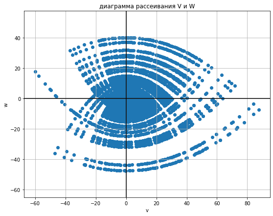

```python
ms = [2, 2]
n_X_Y = 100
sigmaX = 3
sigmaY = 3
DX = sigmaX**2
DY = sigmaY**2
roXY = 0
KXY = ro * sigmaX * sigmaY
cov = [[DX, KXY], [KXY, DY]]
Z = np.random.multivariate_normal(ms, cov, n)
X = Z[:,0]
Y = Z[:,1]
#print('Выборка X:', X)
#print('Выборка Y:', Y)
V = []
W = []
for i in range(n_X_Y):
    for j in range(n_X_Y):
        V.append(X[i]*Y[j])
        W.append(0.5*(X[i]**2 - Y[j]**2))
n = 0
if(len(V) == len(W)):
    n = len(V)
    print("n = ", n)
plt.figure(figsize = (9, 7))
plt.scatter(V, W)
plt.grid(True)
plt.title("диаграмма рассеивания V и W")
plt.xlabel('v')
plt.ylabel('w')
plt.axhline(y = 0, color = 'k')
plt.axvline(x = 0, color = 'k')
plt.axis("equal")

chislitel = 0
alpha = 0.1
m_V = np.mean(V)
m_W = np.mean(W)
D_V = np.var(V, ddof = 1)
D_W = np.var(W, ddof = 1)
sigma_V = np.sqrt(D_V)
sigma_W = np.sqrt(D_W)
print("выборочное мат ожидание V:", m_V)
print("выборочное мат ожидание W:", m_W)
print("выборочная дисперсия V:", D_V)
print("выборочная дисперсия W:", D_W)
for i in range(len(Z_01)):
    chislitel += (V[i] - m_V)*(Z_02[i] - m_W)
roVW = chislitel/((n-1)*sigma_V*sigma_W)
print("коэффициент корреляции Пирсона ro", roVW)
```

```python
print("выборочный коэффициент корреляции Пирсона ro", roVW)
alpha = 0.1
prav_chasch_ner_va = ((sts.t(n-2)).ppf(1-alpha/2))/(np.sqrt(n-2+((sts.t(n-2)).ppf(1-alpha/2))**2))
if(np.abs(roVW) > prav_chasch_ner_va):
    print("Основная гипотеза отклоняется: выборочный к-т корреляции Пирсона статистически значим \n")
    print(np.abs(roVW), ">", prav_chasch_ner_va, "\n")
else:
    print("Основная гипотеза принимается: выборочный к-т корреляции Пирсона статистически не значим\n")
    print(np.abs(roVW), "<=", prav_chasch_ner_va, "\n")
```

```
выборочный коэффициент корреляции Пирсона ro 0.0023292171956925574
Основная гипотеза принимается: выборочный к-т корреляции Пирсона статистически не значим

0.0023292171956925574 <= 0.016449479792248183
```

## Задание 3: В файле «Данные 10_1» приведены результаты наблюдаемых значений шести непрерывных случайных величин. В соответствии с вашим вариантом отберите три выборки и исследуйте их по следующему плану:

1) для каждой пары выборок из вашего набора постройте диаграмму рассеивания; 2) для каждой из трех выборок постройте гистограммы и найдите выборочные характеристики; 3) для каждой пары выборок найдите выборочное значение коэффициента корреляции Пирсона и выборочное значение рангового коэффициента корреляции Спирмена (для визуализации выборочных значений коэффициентов корреляции используйте тепловую карту); сопоставьте результаты; 4) для пары выборок с наименьшим по модулю значением выборочного коэффициента корреляции проверьте гипотезу о значимости коэффициента корреляции Спирмена.

## Решение: $\newline$

Импортируем данные

```python
DATA10_3 = pd.read_excel("Data_10_1.xlsx", header = 0)
D10_3 = pd.DataFrame(DATA10_3)
D10_3 = D10_3.astype(float)
print(D10_3)

sel_1 = D10_3['ОМА'].fillna('-')
sel_2 = D10_3['АиГ'].fillna('-')
sel_3 = D10_3['КПрМА'].fillna('-')

SEL_1 = []
SEL_2 = []
SEL_3 = []

for i in range(len(sel_1)):
    if((sel_1[i] != '-') and (sel_2[i] != '-') and (sel_3[i] != '-')):
        SEL_1.append(sel_1[i])
        SEL_2.append(sel_2[i])
        SEL_3.append(sel_3[i])

print('Выборка №1\n', SEL_1)
print('Выборка №2\n', SEL_2)
print('Выборка №3\n', SEL_3)
```

```
       ОМА  КПрОМА    АиГ  КПрАиГ  КПрМА     ДУ     МА
0    0.581   0.620  0.725   0.862  0.320  0.185  0.155
1    0.580   0.767  0.665   1.000  0.870  0.875  0.714
2    0.860   0.870  0.920   0.920  0.950  0.935  0.867
3    0.650   0.710  0.815   0.880  0.868  0.950  0.873
4    0.520   0.607  0.575   0.864  0.500  0.520  0.520
..     ...     ...    ...     ...    ...    ...    ...
260  0.865   0.950  0.870   0.860  0.868  0.935  0.935
261  0.607   0.726  0.580   0.870  0.730  0.705  0.510
262  0.380   0.520  0.340   0.585  0.520  0.505  0.345
263    NaN     NaN    NaN     NaN  0.300  0.505  0.205
264  0.354   0.710  0.660   0.720  0.240  0.640  0.505

[265 rows x 7 columns]
Выборка №1
 [0.581, 0.58, 0.86, 0.65, 0.52, 0.42, 0.58, 0.595, 0.865, 0.706, 0.58, 0.34, 0.56, 0.7759999999999999, 0.626, 0.611, 0.746, 0.565, 0.52, 0.325, 0.546, 0.5, 0.72, 0.17, 0.34, 0.248, 0.555, 0.32, 0.5, 0.32, 0.581, 0.53, 0.42200000000000004, 0.6, 0.504, 0.56, 0.385, 0.6409999999999999, 0.705, 0.655999…
Выборка №2
 [0.725, 0.665, 0.92, 0.815, 0.575, 0.42, 0.415, 0.46, 0.865, 0.78, 0.6, 0.345, 0.425, 0.875, 0.87, 0.555, 0.7, 0.545, 0.41, 0.405, 0.575, 0.53, 0.89, 0.225, 0.56, 0.12, 0.405, 0.315, 0.665, 0.33, 0.61, 0.54, 0.58, 0.56, 0.45, 0.56, 0.53, 0.57, 0.74, 0.63, 0.41, 0.875, 0.6, 0.57, 0.58, 0.4, 0.42, 0.…
Выборка №3
 [0.32, 0.87, 0.95, 0.868, 0.5, 0.773, 0.54, 0.785, 0.86, 0.86, 0.5, 0.61, 0.6, 0.86, 0.8, 0.655, 0.865, 0.575, 0.26, 0.195, 0.53, 0.02, 0.87, 0.01, 0.35, 0.23, 0.545, 0.03, 0.91, 0.23, 0.723, 0.31, 0.51, 0.8640000000000001, 0.5, 0.575, 0.568, 0.708, 0.873, 0.758, 0.515, 0.768, 0.5, 0.55, 0.748, 0.5…
```

## Пункт 1

```
(-0.017750000000000002, 1.03275, -0.0489, 1.0269)
```

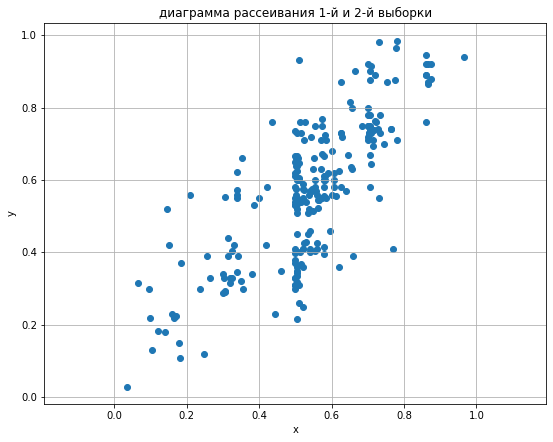

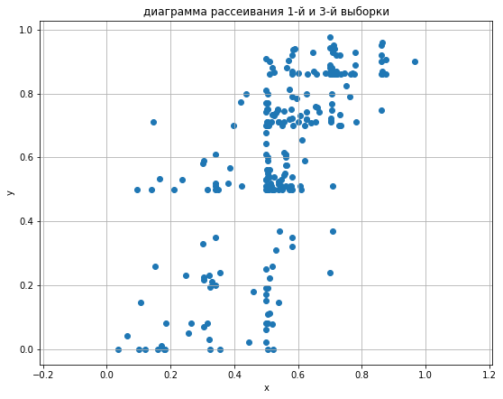

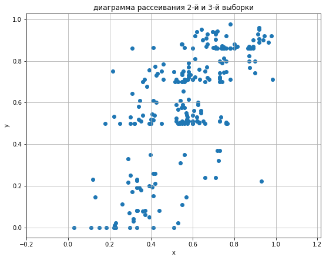

```python
plt.figure(figsize = (9, 7))
plt.scatter(SEL_1, SEL_2)
plt.grid(True)
plt.title("диаграмма рассеивания 1-й и 2-й выборки")
plt.xlabel('x')
plt.ylabel('y')
plt.axis("equal")

plt.figure(figsize = (9, 7))
plt.scatter(SEL_1, SEL_3)
plt.grid(True)
plt.title("диаграмма рассеивания 1-й и 3-й выборки")
plt.xlabel('x')
plt.ylabel('y')
plt.axis("equal")

plt.figure(figsize = (9, 7))
plt.scatter(SEL_2, SEL_3)
plt.grid(True)
plt.title("диаграмма рассеивания 2-й и 3-й выборки")
plt.xlabel('x')
plt.ylabel('y')
plt.axis("equal")
```

## Пункт 2

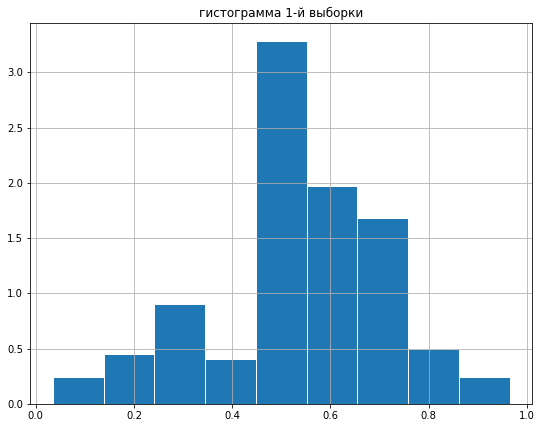

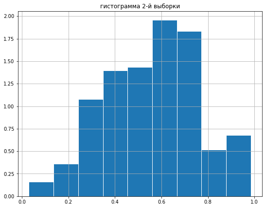

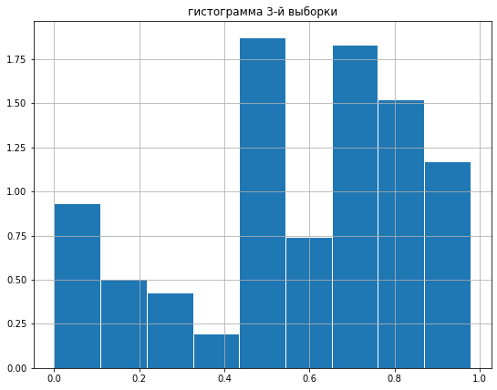

```python
plt.figure(figsize = (9, 7))
plt.hist(SEL_1, bins = 'sturges', edgecolor = 'white', density = True)
plt.grid(True)
plt.title("гистограмма 1-й выборки")

plt.figure(figsize = (9, 7))
plt.hist(SEL_2, bins = 'sturges', edgecolor = 'white', density = True)
plt.grid(True)
plt.title("гистограмма 2-й выборки")

plt.figure(figsize = (9, 7))
plt.hist(SEL_3, bins = 'sturges', edgecolor = 'white', density = True)
plt.grid(True)
plt.title("гистограмма 3-й выборки")
```

## Пункт 3

```
Выборочное мат ожидание 1-й выборки 0.5362819915254237
Выборочное мат ожидание 2-й выборки 0.5670648305084746
Выборочное мат ожидание 3-й выборки 0.5810296610169491
Исправленная выборочная дисперсия 1-й выборки 0.0300827232381446
Исправленная дисперсия 2-й выборки 0.03960085743869455
Исправленная дисперсия 3-й выборки 0.07677620762711865
выборочное значение коэффициента корреляции пирсона 1 и 2 выборки ro12 0.7695059686200355
выборочное значение коэффициента корреляции пирсона 1 и 3 выборки ro13 0.684036622985915
выборочное значение коэффициента корреляции пирсона 2 и 3 выборки ro23 0.01587804809574717
выборочное значение коэффициента ранговой корреляции Спирмена 1 и 2 выборки rs12 0.7507855539096613
выборочное значение коэффициента ранговой корреляции Спирмена 1 и 3 выборки rs13 0.7017454961801074
выборочное значение коэффициента ранговой корреляции Спирмена 2 и 3 выборки rs23 0.6746737879189331
```

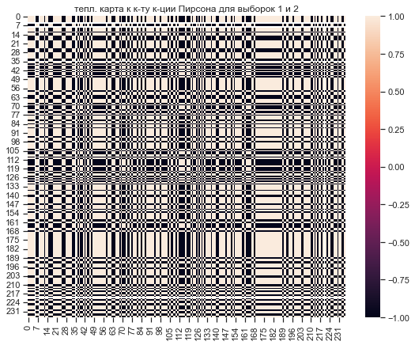

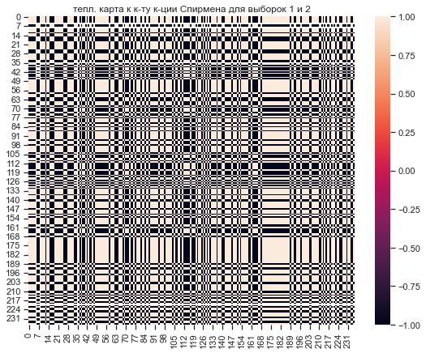

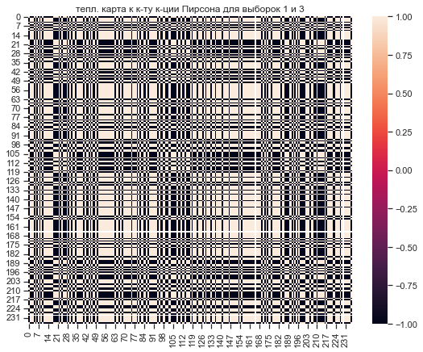

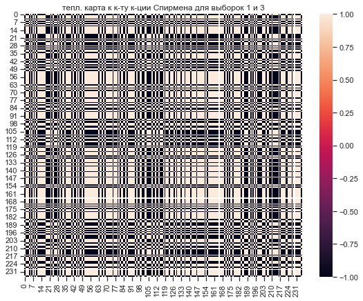

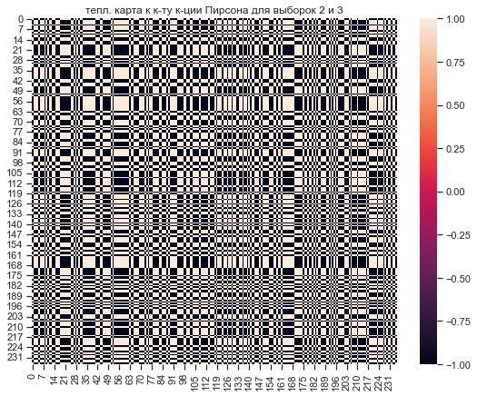

[figure not shown]

```python
chislitel = 0
print("Выборочное мат ожидание 1-й выборки", np.mean(SEL_1))
print("Выборочное мат ожидание 2-й выборки", np.mean(SEL_2))
print("Выборочное мат ожидание 3-й выборки", np.mean(SEL_3))
print("Исправленная выборочная дисперсия 1-й выборки", np.var(SEL_1, ddof = 1))
print("Исправленная дисперсия 2-й выборки", np.var(SEL_2, ddof = 1))
print("Исправленная дисперсия 3-й выборки", np.var(SEL_3, ddof = 1))
for i in range(len(SEL_1)):
    chislitel += (SEL_1[i] - np.mean(SEL_1))*(SEL_2[i] - np.mean(SEL_2))
rz12 = chislitel/((len(SEL_1)-1)*np.sqrt(np.var(SEL_1, ddof = 1))*np.sqrt(np.var(SEL_2, ddof = 1)))
print("выборочное значение коэффициента корреляции пирсона 1 и 2 выборки ro12", rz12)

chislitel = 0
for i in range(len(SEL_1)):
    chislitel += (SEL_1[i] - np.mean(SEL_1))*(SEL_3[i] - np.mean(SEL_3))
rz13 = chislitel/((len(SEL_1)-1)*np.sqrt(np.var(SEL_1, ddof = 1))*np.sqrt(np.var(SEL_3, ddof = 1)))
print("выборочное значение коэффициента корреляции пирсона 1 и 3 выборки ro13", rz13)

chislitel = 0
for i in range(len(SEL_2)):
    chislitel += (SEL_2[i] - np.mean(SEL_2))*(SEL_3[i] - np.mean(SEL_3))
rz23 = chislitel/((n-1)*np.sqrt(np.var(SEL_2, ddof = 1))*np.sqrt(np.var(SEL_3, ddof = 1)))
print("выборочное значение коэффициента корреляции пирсона 2 и 3 выборки ro23", rz23)

rs12, p_value12 = sts.spearmanr(SEL_1, SEL_2, alternative = 'two-sided')
rs13, p_value13 = sts.spearmanr(SEL_1, SEL_3, alternative = 'two-sided')
rs23, p_value23 = sts.spearmanr(SEL_2, SEL_3, alternative = 'two-sided')

print("выборочное значение коэффициента ранговой корреляции Спирмена 1 и 2 выборки rs12", rs12)
print("выборочное значение коэффициента ранговой корреляции Спирмена 1 и 3 выборки rs13", rs13)
print("выборочное значение коэффициента ранговой корреляции Спирмена 2 и 3 выборки rs23", rs23)

s1s2 = []
s1s3 = []
s2s3 = []

s1s2.append(SEL_1)
s1s2.append(SEL_2)
df_s1s2 = pd.DataFrame(s1s2)
corr_pearson12 = df_s1s2.corr()
corr_spearman12 = df_s1s2.corr('spearman')


s1s3.append(SEL_1)
s1s3.append(SEL_3)
df_s1s3 = pd.DataFrame(s1s3)
corr_pearson13 = df_s1s3.corr()
corr_spearman13 = df_s1s3.corr('spearman')


s2s3.append(SEL_2)
s2s3.append(SEL_3)
df_s2s3 = pd.DataFrame(s2s3)
corr_pearson23 = df_s2s3.corr()
corr_spearman23 = df_s2s3.corr('spearman')



plt.figure(figsize = (9, 7))
seaborn.set(style = 'ticks', color_codes = True)
seaborn.heatmap(corr_pearson12, annot = None, fmt = '.4g')
plt.title("тепл. карта к к-ту к-ции Пирсона для выборок 1 и 2")

plt.figure(figsize = (9, 7))
seaborn.set(style = 'ticks', color_codes = True)
seaborn.heatmap(corr_spearman12, annot = None, fmt = '.4g')
plt.title("тепл. карта к к-ту к-ции Спирмена для выборок 1 и 2")

plt.figure(figsize = (9, 7))
seaborn.set(style = 'ticks', color_codes = True)
seaborn.heatmap(corr_pearson13, annot = None, fmt = '.4g')
plt.title("тепл. карта к к-ту к-ции Пирсона для выборок 1 и 3")
plt.figure(figsize = (9, 7))
seaborn.set(style = 'ticks', color_codes = True)
seaborn.heatmap(corr_spearman13, annot = None, fmt = '.4g')
plt.title("тепл. карта к к-ту к-ции Спирмена для выборок 1 и 3")

plt.figure(figsize = (9, 7))
seaborn.set(style = 'ticks', color_codes = True)
seaborn.heatmap(corr_pearson23, annot = None, fmt = '.4g')
plt.title("тепл. карта к к-ту к-ции Пирсона для выборок 2 и 3")
plt.figure(figsize = (9, 7))
seaborn.set(style = 'ticks', color_codes = True)
seaborn.heatmap(corr_spearman12, annot = None, fmt = '.4g')
plt.title("тепл. карта к к-ту к-ции Спирмена для выборок 2 и 3")
```

## Пункт 4: проведем проверку гипотезы о значимости коэффициента корреляции Спирмена для 2-й и 3-й выборок. $\newline$

Основная гипотеза $H_0: \rho = 0$ $\newline$ Альтернативная гипотеза: $H_1: \rho \ne 0$ $\newline$ Воспользуемся встроенной в питон функцией sts.spearmanr()

```python
rs23, p_value23 = sts.spearmanr(SEL_2, SEL_3, alternative='two-sided')
print("При уровне значимости alpha <", p_value23, "основная гипотеза принимается")
print("При уровне значимости alpha >=", p_value23, "основная гипотеза отклоняется, принимается альтернативная гипотеза")
```

```
При уровне значимости alpha < 1.0635658481793903e-32 основная гипотеза принимается
При уровне значимости alpha >= 1.0635658481793903e-32 основная гипотеза отклоняется, принимается альтернативная гипотеза
```

$\newline$

## Задание 4: Пусть генеральная совокупность имеет нормальный закон распределения. Что можно сказать о наличии корреляционной зависимости между случайными величинами – выборочной оценкой математического ожидания и исправленной выборочной дисперсией? Для выдвижения гипотезы используйте статистический эксперимент.

## Решение: рассмотрим генеральную совокупность, имеющую нормальное распределение с параметрами $m = 3$, $\sigma = 5$. Составим $n = 1000$ выборок объема $size = 10000$, для каждой из них посчитаем выборочное мат. ожидание, исправленную выборочную дисперсию и найдем выборочный коэффициент корреляции.

```
выборочное мат ожидание выборки мат. ожиданий: 2.999199326350914
выборочное мат ожидание выборки испр. дисперсий: 24.99935960918216
исправленная выборочная дисперсия мат. ожиданий: 0.002518045143915018
исправленная выборочная дисперсия выборки испр. дисперсий: 0.12442429867651361
выборочный коэффициент корреляции Пирсона выборок: 0.35829132155443044
```

```
(2.8217275592727415, 3.198084716823346, 23.72489531226488, 26.347723909032087)
```

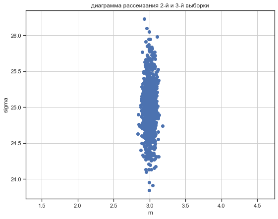

```python
m = 3
sigma = 5
n = 1000
size = 10000
m_sels = []
s2_sels = []
for i in range(n):
    selection = np.random.normal(m, sigma, size)
    m_sel = np.mean(selection)
    s2_sel = np.var(selection, ddof = 1)
    m_sels.append(m_sel)
    s2_sels.append(s2_sel)
#print("Выборка выборочных мат ожиданий:", m_sels, "\n")
#print("Выборка исправленных выборочных дисперсий:", s2_sels, "\n")

chislitel = 0
m_m_sels = np.mean(m_sels)
m_s2_sels = np.mean(s2_sels)
D_m_sels = np.var(m_sels, ddof = 1)
D_s2_sels = np.var(s2_sels, ddof = 1)
sigma_m_sels = np.sqrt(D_m_sels)
sigma_s2_sels = np.sqrt(D_s2_sels)
print("выборочное мат ожидание выборки мат. ожиданий:", m_m_sels)
print("выборочное мат ожидание выборки испр. дисперсий:", m_s2_sels)
print("исправленная выборочная дисперсия мат. ожиданий:", D_m_sels)
print("исправленная выборочная дисперсия выборки испр. дисперсий:", D_s2_sels)
for i in range(n):
    chislitel += (m_sels[i] - m_m_sels)*(s2_sels[i] - m_s2_sels)
ro = chislitel/((n-1)*sigma_m_sels*sigma_m_sels)
print("выборочный коэффициент корреляции Пирсона выборок:", ro)

plt.figure(figsize = (9, 7))
plt.scatter(m_sels, s2_sels)
plt.grid(True)
plt.title("диаграмма рассеивания 2-й и 3-й выборки")
plt.xlabel('m')
plt.ylabel('sigma')
plt.axis("equal")
```

Проверим статистическую значимость выборочного коэффициента корреляции. Основная гипотеза: $$H_0: \rho = 0$$ Альтернативная гипотеза: $$H_1: \rho \ne 0$$ Возьмем уровень значимости $\alpha = 0.1$ Будем пользоваться критерием, критическая область которого, учитывая введенную альтернативную гипотезу, определяется неравенством: $$|r| \gt \frac{t_{1-\alpha/2}(n - 2)}{\sqrt{n-2+t_{1-\alpha/2}^2(n - 2)}}$$

```python
print("выборочный коэффициент корреляции Пирсона ro", ro)
alpha = 0.1
prav_chasch_ner_va = ((sts.t(n-2)).ppf(1-alpha/2))/(np.sqrt(n-2+((sts.t(n-2)).ppf(1-alpha/2))**2))
if(np.abs(ro) > prav_chasch_ner_va):
    print("Основная гипотеза отклоняется, выборочный к-т кореляции Пирсона значим\n")
    print(np.abs(ro), ">", prav_chasch_ner_va, "\n")
else:
    print("Основная гипотеза принимается, выборочный к-т кореляции Пирсона не значим\n")
    print(np.abs(ro), "<=", prav_chasch_ner_va, "\n")
```

```
выборочный коэффициент корреляции Пирсона ro 0.35829132155443044
Основная гипотеза отклоняется, выборочный к-т кореляции Пирсона значим

0.35829132155443044 > 0.05204467879032861
```